# Practical1

# Make your own data frame

A data frame is a special kind of object for storing and managing data sets of rectangular structure.  
As we saw in the videos, in the context of multivariate data analysis, the rows typically correspond to  
the samples and the columns typically correspond to variables. Each column is a vector so  
must contain data which are all of the same type. However, different columns can contain different  
types of data.

## Useful data frame functions

1. dim(): shows the dimensions of the data frame by row and column
2. str(): shows the structure of the data frame
3. summary(): provides summary statistics on the columns of the data frame
4. colnames(): shows the name of each column in the data frame
5. rownames(): shows the name of each row in the data frame
6. ncol(): Number of columns
7. nrow(): Number of rows
8. head(): shows the first 6 rows of the data frame
9. tail(): shows the last 6 rows of the data frame
10. View(): shows a spreadsheet-like display of the entire data frame
11. cbind(): Column bind - combine multiple data frames side-by-side
12. rbind(): Row bind - stack multiple data frames on top of each other

### Lets create a data frame

One way to create a data frame is to use the data.frame function. For example,

```r
age = c(24, 26, 25, 21)
gender = c("Male", "Female", "Male", "Female")
respond = c(TRUE, FALSE, FALSE, FALSE)
df = data.frame(age=age, gender=gender, respond=respond)
df
```

| age | gender | respond |
| --- | --- | --- |
| 24 | Male | TRUE |
| 26 | Female | FALSE |
| 25 | Male | FALSE |
| 21 | Female | FALSE |

### Task 1: Before checking your answers in R, try to work out the result of each of the extraction operations below

```r
df[4, 1]
```

```
[1] 21
```

```r
df[,3]
```

```
[1]  TRUE FALSE FALSE FALSE
```

```r
df[2,]
```

|  | age | gender | respond |
| --- | --- | --- | --- |
| 2 | 26 | Female | FALSE |

```r
df$age
```

```
[1] 24 26 25 21
```

```r
df[1:2, 2]
```

```
[1] "Male"   "Female"
```

```r
df[1:3, c(1,3)]
```

|  | age | respond |
| --- | --- | --- |
| 1 | 24 | TRUE |
| 2 | 26 | FALSE |
| 3 | 25 | FALSE |

```r
age = c(27, 28, 29, 30)
gender = c("Male", "Female", "Male", "Female")
respond = c(TRUE, FALSE, FALSE, FALSE)
df2 = data.frame(age=age, gender=gender, respond=respond)
df = rbind(df, df2)
```

### Task 3: make another data frame and combine it with the one above to make a taller data frame

```r
age = c(31, 32, 33, 34)
gender = c("Male", "Female", "Male", "Female")
respond = c(TRUE, FALSE, FALSE, FALSE)
df3 = data.frame(age=age, gender=gender, respond=respond)
df = rbind(df, df3)
```

### Task 4: view your new data frame using the useful commands above

```r
df
```

[output not shown]

# A bit of basic coding for warm up

You’ve been working with R for a few weeks now. Using R we want to code up some of the functions that were mentioned in the week 1.1 videos. R already includes functions to calculate mean, variance and covariance. But here the aim is to get back to the basics and also understand how these functions work. These are the rule for the following tasks:

**You can only use these commands:**

- **for loops, e.g.**

  `for(i in vec) {`

  `# R code we wish to repeat # ...`

  `}`

  or

  `for(i in 1:10) {`

  `# R code we wish to repeat # ...`

  `}`
- **the basic data frame commands (i.e. loading the data frame, calling a particular column/row/element, etc)**

### Task 5.1: upload the heptathlon data from the nclSLR package

```r
library(nclSLR)
data("heptathlon")
head(heptathlon)
```

|  | H100M | HJ | SP | R200M | LJ | JT | R800M |
| --- | --- | --- | --- | --- | --- | --- | --- |
| Jessica Ennis (GBR) | 12.54 | 1.86 | 14.28 | 22.83 | 6.48 | 47.49 | 128.65 |
| Lilli Schwarzkopf (GER) | 13.26 | 1.83 | 14.77 | 24.77 | 6.30 | 51.73 | 130.50 |
| Austra Skujyte (LTU) | 14.00 | 1.92 | 17.31 | 25.43 | 6.25 | 51.13 | 140.59 |
| Antoinette Nana Djimou Ida (FRA) | 12.96 | 1.80 | 14.26 | 24.72 | 6.13 | 55.87 | 133.62 |
| Jessica Zelinka (CAN) | 12.65 | 1.68 | 14.81 | 23.32 | 5.91 | 45.75 | 129.15 |
| Kristina Savitskaya (RUS) | 13.37 | 1.83 | 14.77 | 24.46 | 6.21 | 43.70 | 132.27 |

### Task 5.2: find the mean of each sporting category, make a copy of your heptathlon data frame and add a row to the bottom of it with the mean values

```r
library(dplyr)
mean_values <- heptathlon %>%
  summarise(across(where(is.numeric), mean, na.rm = TRUE))
heptathlon_mean_sd <- rbind(heptathlon, mean_values)
rownames(heptathlon_mean_sd)[nrow(heptathlon_mean_sd)] <- "Mean"
print(heptathlon_mean_sd)
```

|  | H100M | HJ | SP | R200M | LJ | JT | R800M |
| --- | --- | --- | --- | --- | --- | --- | --- |
| Jessica Ennis (GBR) | 12.54000 | 1.860000 | 14.2800 | 22.83000 | 6.480000 | 47.49000 | 128.6500 |
| Lilli Schwarzkopf (GER) | 13.26000 | 1.830000 | 14.7700 | 24.77000 | 6.300000 | 51.73000 | 130.5000 |
| Austra Skujyte (LTU) | 14.00000 | 1.920000 | 17.3100 | 25.43000 | 6.250000 | 51.13000 | 140.5900 |
| Antoinette Nana Djimou Ida (FRA) | 12.96000 | 1.800000 | 14.2600 | 24.72000 | 6.130000 | 55.87000 | 133.6200 |
| Jessica Zelinka (CAN) | 12.65000 | 1.680000 | 14.8100 | 23.32000 | 5.910000 | 45.75000 | 129.1500 |
| Kristina Savitskaya (RUS) | 13.37000 | 1.830000 | 14.7700 | 24.46000 | 6.210000 | 43.70000 | 132.2700 |
| Laura Ikauniece (LAT) | 13.71000 | 1.830000 | 12.6400 | 24.16000 | 6.130000 | 51.27000 | 132.1300 |
| Hanna Melnychenko (UKR) | 13.32000 | 1.800000 | 12.9600 | 24.09000 | 6.400000 | 43.86000 | 132.9000 |
| Brianne Theisen (CAN) | 13.30000 | 1.830000 | 12.8900 | 24.35000 | 6.010000 | 46.47000 | 129.2700 |
| Dafne Schippers (NED) | 13.48000 | 1.800000 | 13.6700 | 22.83000 | 6.280000 | 36.63000 | 135.5200 |

[output cut: 20 more lines]

### Task 5.3: find the standard deviation for each sporting category and add a row with these values to the bottom of your new data frame

```r
library(dplyr)
sd_values <- heptathlon %>%
  summarise(across(where(is.numeric), sd , na.rm = TRUE))
heptathlon_mean_sd <- rbind(heptathlon, sd_values)
rownames(heptathlon_mean_sd)[nrow(heptathlon_mean_sd)] <- "SD"
print(heptathlon_mean_sd)
```

|  | H100M | HJ | SP | R200M | LJ | JT | R800M |
| --- | --- | --- | --- | --- | --- | --- | --- |
| Jessica Ennis (GBR) | 12.5400000 | 1.860000 | 14.280000 | 22.830000 | 6.4800000 | 47.490000 | 128.650000 |
| Lilli Schwarzkopf (GER) | 13.2600000 | 1.830000 | 14.770000 | 24.770000 | 6.3000000 | 51.730000 | 130.500000 |
| Austra Skujyte (LTU) | 14.0000000 | 1.920000 | 17.310000 | 25.430000 | 6.2500000 | 51.130000 | 140.590000 |
| Antoinette Nana Djimou Ida (FRA) | 12.9600000 | 1.800000 | 14.260000 | 24.720000 | 6.1300000 | 55.870000 | 133.620000 |
| Jessica Zelinka (CAN) | 12.6500000 | 1.680000 | 14.810000 | 23.320000 | 5.9100000 | 45.750000 | 129.150000 |
| Kristina Savitskaya (RUS) | 13.3700000 | 1.830000 | 14.770000 | 24.460000 | 6.2100000 | 43.700000 | 132.270000 |
| Laura Ikauniece (LAT) | 13.7100000 | 1.830000 | 12.640000 | 24.160000 | 6.1300000 | 51.270000 | 132.130000 |
| Hanna Melnychenko (UKR) | 13.3200000 | 1.800000 | 12.960000 | 24.090000 | 6.4000000 | 43.860000 | 132.900000 |
| Brianne Theisen (CAN) | 13.3000000 | 1.830000 | 12.890000 | 24.350000 | 6.0100000 | 46.470000 | 129.270000 |
| Dafne Schippers (NED) | 13.4800000 | 1.800000 | 13.670000 | 22.830000 | 6.2800000 | 36.630000 | 135.520000 |

[output cut: 20 more lines]

### Task 5.4: create a covariance matrix for your original data frame

```r
heptathlon_numeric <- heptathlon[, sapply(heptathlon, is.numeric)]
manual_cov <- function(x, y,z) {
  mean_x <- mean(x)
  mean_y <- mean(y)
  sum((x - mean_x) * (y - mean_y)) / (z- 1)
}
n <- ncol(heptathlon_numeric)
cov_matrix <- matrix(NA, n, n)
colnames(cov_matrix) <- colnames(heptathlon_numeric)
rownames(cov_matrix) <- colnames(heptathlon_numeric)
for (i in 1:n) {
  for (j in i:n) {
    cov_value <- manual_cov(heptathlon_numeric[, i], heptathlon_numeric[, j], length(heptathlon_numeric[, i]))
    cov_matrix[i, j] <- cov_value
    cov_matrix[j, i] <- cov_value
  }
}
print(cov_matrix)
```

```
             H100M           HJ          SP        R200M          LJ          JT       R800M
H100M  0.233480542 -0.003236453 -0.08428534  0.264269335 -0.09268695 -0.56429273  1.15053670
HJ    -0.003236453  0.006324384  0.01539495 -0.008963054  0.01890850 -0.00756835 -0.22557894
SP    -0.084285345  0.015394951  1.51165074  0.110874384 -0.06231675  2.11291453 -0.01903017
R200M  0.264269335 -0.008963054  0.11087438  0.693497537 -0.13611342  1.42318670  2.54420788
LJ    -0.092686946  0.018908498 -0.06231675 -0.136113424  0.18704631  0.02329680 -1.28646490
JT    -0.564292734 -0.007568350  2.11291453  1.423186700  0.02329680 27.65580246  1.06724828
R800M  1.150536700 -0.225578941 -0.01903017  2.544207882 -1.28646490  1.06724828 43.98550764
```

### Task 5.5: create a correlation matrix for your original data frame

```r
manual_cor <- function(x, y) {
  x <- as.numeric(x)
  y <- as.numeric(y)
  n <- length(x)
  mean_x <- mean(x)
  mean_y <- mean(y)
  numerator <- sum((x - mean_x) * (y - mean_y))
  denominator <- sqrt(sum((x - mean_x)^2) * sum((y - mean_y)^2))
  numerator / denominator
}
n <- ncol(heptathlon_numeric)
cor_matrix <- matrix(NA, n, n)
colnames(cor_matrix) <- colnames(heptathlon_numeric)
rownames(cor_matrix) <- colnames(heptathlon_numeric)
for (i in 1:n) {
  for (j in i:n) {
    cor_value <- manual_cor(heptathlon_numeric[, i], heptathlon_numeric[, j])
    cor_matrix[i, j] <- cor_value
    cor_matrix[j, i] <- cor_value
  }
}
print(cor_matrix)
```

```
            H100M          HJ           SP      R200M          LJ          JT        R800M
H100M  1.00000000 -0.08422381 -0.141873405  0.6567483 -0.44352557 -0.22206800  0.359021391
HJ    -0.08422381  1.00000000  0.157450284 -0.1353395  0.54976024 -0.01809668 -0.427695445
SP    -0.14187340  0.15745028  1.000000000  0.1082887 -0.11719376  0.32678572 -0.002333792
R200M  0.65674831 -0.13533946  0.108288672  1.0000000 -0.37792353  0.32497225  0.460654511
LJ    -0.44352557  0.54976024 -0.117193760 -0.3779235  1.00000000  0.01024303 -0.448506323
JT    -0.22206800 -0.01809668  0.326785718  0.3249723  0.01024303  1.00000000  0.030599725
R800M  0.35902139 -0.42769545 -0.002333792  0.4606545 -0.44850632  0.03059973  1.000000000
```

## From here on you can use any R command

### Task 5.6 compare your results with the pre-made functions in R (you should get the same result)

```r
## you can use, colMeans(), var() and cor()
cov_matrix <- cov(heptathlon[, colnames(heptathlon)])
cov_matrix
```

```
             H100M           HJ          SP        R200M          LJ          JT       R800M
H100M  0.233480542 -0.003236453 -0.08428534  0.264269335 -0.09268695 -0.56429273  1.15053670
HJ    -0.003236453  0.006324384  0.01539495 -0.008963054  0.01890850 -0.00756835 -0.22557894
SP    -0.084285345  0.015394951  1.51165074  0.110874384 -0.06231675  2.11291453 -0.01903017
R200M  0.264269335 -0.008963054  0.11087438  0.693497537 -0.13611342  1.42318670  2.54420788
LJ    -0.092686946  0.018908498 -0.06231675 -0.136113424  0.18704631  0.02329680 -1.28646490
JT    -0.564292734 -0.007568350  2.11291453  1.423186700  0.02329680 27.65580246  1.06724828
R800M  1.150536700 -0.225578941 -0.01903017  2.544207882 -1.28646490  1.06724828 43.98550764
```

```r
## Compare cor() for the original data frame with cor() for the scaled data frame. You can use scale() make a scaled data frame.
correlation_matrix <- cor(heptathlon[, colnames(heptathlon)])
correlation_matrix
```

```
            H100M          HJ           SP      R200M          LJ          JT        R800M
H100M  1.00000000 -0.08422381 -0.141873405  0.6567483 -0.44352557 -0.22206800  0.359021391
HJ    -0.08422381  1.00000000  0.157450284 -0.1353395  0.54976024 -0.01809668 -0.427695445
SP    -0.14187340  0.15745028  1.000000000  0.1082887 -0.11719376  0.32678572 -0.002333792
R200M  0.65674831 -0.13533946  0.108288672  1.0000000 -0.37792353  0.32497225  0.460654511
LJ    -0.44352557  0.54976024 -0.117193760 -0.3779235  1.00000000  0.01024303 -0.448506323
JT    -0.22206800 -0.01809668  0.326785718  0.3249723  0.01024303  1.00000000  0.030599725
R800M  0.35902139 -0.42769545 -0.002333792  0.4606545 -0.44850632  0.03059973  1.000000000
```

### Task 5.8 make a scatter plot of the data frame (you can use `pairs(dataframe_name)` )

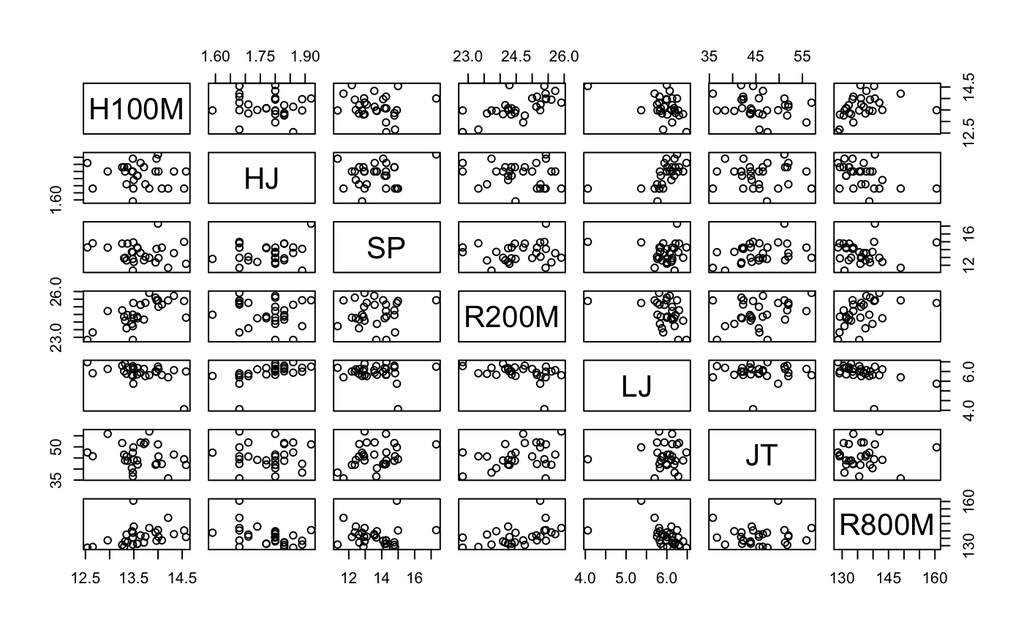

```r
pairs(heptathlon, colnames(heptathlon))
```

### Task 6: Another Loop exercise

1. Simulate 100 random variables drawn from a normal distribution with mean 5 and standard deviation 2
2. Find the mean and standard deviation of your sample (which is going to be close to your inputs but not exactly equal)
3. Make a new vector that is the normalised version of part 1
   1. Do this once using a for loop
   2. Do this using the R vectorised language (without a for loop)

```r
### use rnorm
```

## Conditional statements

### Task 7: Before checking your answers in R, try to work out the values assigned to z and w in the following blocks of code.

```r
x = 5
y = "Male"
if((x > 0) & (y == "male")){
z = 0
} else if((x > 0) & (y == "female")) {
z = 1
} else {
z = 2
}
##what is z?
z IS 2
```

```
Error: unexpected symbol in "z IS"
```

```r
v = TRUE
if(!v) {
w = FALSE
} else {
w = TRUE
}
##what is w?

#Its is TRUE
```

## Finding values that fit a condition

You can use logical values to choose certain elements of a vector. Run the next chunk to see how vec1 looks like.

```r
vec1 = seq(0, 10, 2)
vec1
```

Before running the next line try to predict what it does

```r
vec1[c(FALSE, FALSE, TRUE, TRUE, FALSE)]
```

What do you think the following line will produce?

```r
vec1>3
```

And what about this?

```r
vec1[vec1>3]
```

You can use > and < to produce the same result as `vec1[c(FALSE, FALSE, TRUE, TRUE, FALSE)]`. Write it down in the next chunk

### Task 8.1: going back to the heptathlon data find all athletes that performed better than average in each category.

(reminder: each column of a data frame is a vector)

### Task 8.2: Find all athletes that performed better than average in 2,3,… categories